# Práctica 2 - Tipología y ciclo de vida de los datos

Autores: Adrián Barrios Trujillo, Anna Barrera Quintanilla

Instalamos y cargamos los paquetes necesarios para la ejecución de nuestro script:

```r
packages <- c("rstudioapi", "dplyr", "DescTools", "FactoMineR", "rgl")

for (pkg in packages) {
  if (!requireNamespace(pkg, quietly = TRUE)) {
    install.packages(pkg)
  }
}

library(rstudioapi)
library(stringr)
library(DescTools)
library(FactoMineR)
library(rgl)
library(scatterplot3d)
library(ggplot2)
library(dplyr)
```

## Carga de los datos

Obtenemos el directorio del script actual y lo establecemos como directorio de trabajo

```r
path <- dirname(rstudioapi::getActiveDocumentContext()$path)
setwd(path)
```

Leemos el archivo CSV original, teniendo en cuenta que emplea como separador el punto y coma (“;”) y posee cabecera:

```r
dataset <- read.csv(paste0(path, "/data/films.csv") ,sep=";")
```

## Descripción del dataset

```r
head(dataset)
```

```
##                      title year    rating                         studio
## 1           Dekalog (1988) 1996     TV-MA Facets Multimedia Distribution
## 2            The Godfather 1972         R             Paramount Pictures
## 3              Tokyo Story 1972 Not Rated               New Yorker Films
## 4             Citizen Kane 1941  Approved             Paramount Pictures
## 5                  Boyhood 2014         R                      IFC Films
## 6 The Leopard (re-release) 2004  Approved          Twentieth Century Fox
##   duration must_see metascore user_score number_critics number_users
## 1 9 h 32 m    False       100        7.5             13          100
## 2 2 h 55 m     True       100        9.3             16            3
## 3 2 h 16 m     True       100        8.2             19          132
## 4 1 h 59 m     True       100        8.3             19          875
## 5 2 h 45 m     True       100        7.5             50            2
## 6  3 h 6 m    False       100        7.9             12           77
##            genre             director
```

[output cut: 20 more lines]

Tras esto, comprobamos el tipo de datos del dataset; para ello, emplearemos tanto str() como summary():

```r
str(dataset)
```

```
## 'data.frame':    2596 obs. of  14 variables:
##  $ title         : chr  "Dekalog (1988)" "The Godfather" "Tokyo Story" "Citizen Kane" ...
##  $ year          : int  1996 1972 1972 1941 2014 2004 1970 1994 2002 1943 ...
##  $ rating        : chr  "TV-MA" "R" "Not Rated" "Approved" ...
##  $ studio        : chr  "Facets Multimedia Distribution" "Paramount Pictures" "New Yorker Films" "Paramount Pictures" ...
##  $ duration      : chr  "9 h 32 m" "2 h 55 m" "2 h 16 m" "1 h 59 m" ...
##  $ must_see      : chr  "False" "True" "True" "True" ...
##  $ metascore     : int  100 100 100 100 100 100 100 100 100 100 ...
##  $ user_score    : chr  "7.5" "9.3" "8.2" "8.3" ...
##  $ number_critics: int  13 16 19 19 50 12 11 11 8 18 ...
##  $ number_users  : num  100 3 132 875 2 77 101 230 426 581 ...
##  $ genre         : chr  "Drama" "Crime, Drama" "Drama" "Drama, Mystery" ...
##  $ director      : chr  "Krzysztof Kieslowski" "Francis Ford Coppola" "Yasujirô Ozu" "Orson Welles" ...
##  $ writer        : chr  "Krzysztof Kieslowski, Krzysztof Piesiewicz" "Mario Puzo, Francis Ford Coppola" "Kôgo Noda, Yasujirô Ozu" "Herman J. Mankiewicz, John Houseman, Roger Q. Denny, Mollie Kent, Orson Welles" ...
##  $ summary       : chr  "This masterwork by Krzysztof Kieślowski is one of the twentieth century’s greatest achievements in visual story"| __truncated__ "Francis Ford Coppola's epic features Marlon Brando in his Oscar-winning role as the patriarch of the Corleone f"| __truncated__ "Yasujiro Ozu’s…
```

```r
summary(dataset)
```

```
##     title                year         rating             studio
##  Length:2596        Min.   :1916   Length:2596        Length:2596
##  Class :character   1st Qu.:1996   Class :character   Class :character
##  Mode  :character   Median :2010   Mode  :character   Mode  :character
##                     Mean   :2003
##                     3rd Qu.:2018
##                     Max.   :2024
##                     NA's   :24
##    duration           must_see           metascore       user_score
##  Length:2596        Length:2596        Min.   : 77.00   Length:2596
##  Class :character   Class :character   1st Qu.: 79.00   Class :character
##  Mode  :character   Mode  :character   Median : 82.00   Mode  :character
##                                        Mean   : 83.44
##                                        3rd Qu.: 86.00
##                                        Max.   :100.00
##
##  number_critics   number_users      genre             director
##  Min.   : 7.00   Min.   :  1.0   Length:2596        Length:2596
##  1st Qu.:13.00   1st Qu.: 11.0   Class :character   Class :character
##  Median :19.00   Median : 31.0   Mode  :character   Mode  :character
##  Mean   :22.45   Mean   :105.9
##  3rd Qu.:30.00   3rd Qu.:111.0
##  Max.   :69.00   Max.   :997.0
##                  NA's   :488
##     writer            summary
##  Length:2596        Length:2596
##  Class :character   Class :character
##  Mode  :character   Mode  :character
##
##
##
##
```

El dataset “films.csv” contiene 2596 filas repartidas en 14 columnas, y cuyos datos contienen información sobre el top de películas recogidas desde la página web Metacritic (https://www.metacritic.com/). Los campos son:

- title: título de la película.
- year: año de salida.
- rating: clasificación por edades.
- studio: compañía de producción de la película.
- duration: duración en horas y minutos (formato X h YY m).
- must_see: etiqueta “MUST-SEE” de Metacritic como recomendación de la página web.
- metascore: puntuación recibida por los críticos de Metacritic.
- user_score: puntuación recibida por los usuarios de la página.
- number_critics: número de críticos que han calificado la película.
- number_users: número de usuarios que han calificado la película.
- genre: género de la película.
- director: director/a o directores de la película.
- writer: escritor/a o escritores de la película.
- summary: resumen del argumento de la película.

Nuestro objetivo es analizar qué películas reciben la etiqueta “MUST-SEE” (campo ‘must_see’) de Metacritic, empleando las otras características presentes en el dataset. Para ello, haremos uso de la información recogida previamente con str() y summary() para comprobar el estado de los datos y prepararlos para los algoritmos que usaremos en nuestro análisis.

Primero, podemos observar que hay algunos campos que presentan valores nulos, como ‘year’ o ‘number_users’; por tanto, tendremos que lidiar con ello en la limpieza que realizaremos más adelante, según la naturaleza de cada uno de ellos.

También hemos visto que hay campos de valor numérico que tienen asignado el tipo “character” o que son de tipo ‘numeric’ cuando podrían ser de tipo ‘integer’; por tanto, es recomendable pasarlos a un tipo más adecuado según corresponda. Estos campos son: ‘user-score’ (es tipo ‘character’ cuando debería ser ‘integer’) y ‘number_users’ (es de tipo ‘numeric’, y lo pasaremos a ‘integer’). Además, los campos numéricos, en caso de ser usados más adelante, deberán escalarse para un mejor análisis.

Respecto a las variables categóricas, tendríamos que revisar sus valores para ver si podríamos codificarlas de manera que podamos aplicar los algoritmos sin que presenten muchas dificultades o, si por el contrario, sería mejor no emplearlas.

Por último, la variable ‘must_see’ es de tipo ‘character’, pero sus valores son de tipo booleano, es decir, “True” y “False”. Emplearemos este campo como variable objetivo por lo que, para facilitar su uso, también codificaremos este campo en el siguiente apartado.

## Integración y selección de los datos de interés a analizar

En nuestro análisis, hemos considerado que algunas variables podrían presentar valores poco útiles o generar demasiado ruido en nuestro modelos. En este caso, hacemos referencia a una serie de campos categóricos que, como explicaremos más adelante, dificultarían nuestro análisis. El listado es el siguiente:

- title
- studio
- director
- writer
- summary

Para empezar, ‘title’ se refiere al nombre de cada película, por lo que no es una característica que nos pueda servir para encontrar patrones o rasgos comunes entre ellas; lo mismo sucede con la descripción o resumen (‘summary’), que debería ser única para cada película. Comprobemos el total de valores únicos para cada uno de estos campos, que debería ser igual o similar (si hay filas o valores repetidos puede afectar a este número) al total de observaciones (2596):

El número de títulos distintos es:

```r
dataset$title %>% unique() %>% length()
```

```
## [1] 2574
```

El número de títulos repetidos es:

```r
dataset$title[duplicated(dataset$title)] %>% unique() %>% length()
```

```
## [1] 19
```

El número de resúmenes distintos es:

```r
dataset$summary %>% unique() %>% length()
```

```
## [1] 2589
```

El número de resúmenes repetidos es:

```r
dataset$summary[duplicated(dataset$summary)] %>% unique() %>% length()
```

```
## [1] 7
```

Tanto el número de títulos como el número de resúmenes es prácticamente igual al total de observaciones, y aunque podemos ver que hay algunos datos repetidos en ambos campos, nuestro argumento sigue siendo el mismo: son demasiadas características diferentes como para poder detectar alguna semejanza entre las películas.

Respecto al resto, ‘studio’, ‘director’ y ‘writer’ presentan también una gran cantidad de combinaciones diferentes que dificultarían nuestra labor:

El número de estudios distintos es:

```r
dataset$studio %>% unique() %>% length()
```

```
## [1] 459
```

El número de directores distintos es:

```r
dataset$director %>% paste(., collapse = ",") %>% strsplit(",") %>% unlist() %>% trimws() %>% unique() %>% length()
```

```
## [1] 1760
```

El número de escritores distintos es:

```r
dataset$writer %>% paste(., collapse = ",") %>% strsplit(",") %>% unlist() %>% trimws() %>% unique() %>% length()
```

```
## [1] 3697
```

Para empezar, ‘studio’ contiene 459 datos únicos, es decir, hay 459 compañías diferentes encargadas de producir las películas de este dataset; dicho número sigue siendo lo suficientemente grande como para dificultar el rendimiento de nuestros algoritmos.

Si hablamos de los directores y escritores implicados, hemos aislado primero el nombre de cada uno, dado que podían haber uno o varios (incluso ninguno) para cada película, y luego hemos comprobado el número de valores únicos; pese a ello, seguían siendo demasiados: 1760 directores diferentes y 3697 escritores.

Por tanto, dada la gran cantidad de distintos valores presentes en cada una de estas columnas, las eliminaremos, de forma que faciliten nuestro uso:

```r
dataset <- dataset %>% dplyr::select(-title, -studio, -director, -writer, -summary)
dataset %>% str()
```

```
## 'data.frame':    2596 obs. of  9 variables:
##  $ year          : int  1996 1972 1972 1941 2014 2004 1970 1994 2002 1943 ...
##  $ rating        : chr  "TV-MA" "R" "Not Rated" "Approved" ...
##  $ duration      : chr  "9 h 32 m" "2 h 55 m" "2 h 16 m" "1 h 59 m" ...
##  $ must_see      : chr  "False" "True" "True" "True" ...
##  $ metascore     : int  100 100 100 100 100 100 100 100 100 100 ...
##  $ user_score    : chr  "7.5" "9.3" "8.2" "8.3" ...
##  $ number_critics: int  13 16 19 19 50 12 11 11 8 18 ...
##  $ number_users  : num  100 3 132 875 2 77 101 230 426 581 ...
##  $ genre         : chr  "Drama" "Crime, Drama" "Drama" "Drama, Mystery" ...
```

## Limpieza de datos

Comenzamos este apartado con la limpieza de los valores nulos: recordemos que ‘year’ y ‘number_users’ ya nos presentaron antes este tipo de valores. Para ‘year’ podemos ver que son solo 24 valores nulos; por tanto, al ser una cantidad lo suficientemente pequeña, podemos eliminar estas filas de nuestro dataset.

```r
cleanData <- dataset[!is.na(dataset$year),]
```

Sin embargo, ‘number_users’ presenta un mayor número de valores NA: un total de 488 observaciones. Por tanto, tendremos que analizar previamente su impacto junto al campo ‘user_score’, dada la relación entre ambos:

```r
dataUsers <- cleanData %>% dplyr::filter(is.na(cleanData$number_users)) %>% dplyr::select(user_score, number_users)
dataUsers %>% head()
```

```
##   user_score number_users
## 1        tbd           NA
## 2        tbd           NA
## 3        tbd           NA
## 4        tbd           NA
## 5        tbd           NA
## 6        tbd           NA
```

Número de filas presentes en dataUsers, es decir, número de observaciones que tienen valor NA en ‘number_users’:

```r
dataUsers %>% nrow()
```

```
## [1] 464
```

Puntuaciones únicas cuando number_users es NA:

```r
dataUsers$user_score %>% table()
```

```
## .
## 2.5 3.0 4.0 4.3 4.5 4.8 5.0 5.3 5.5 5.8 6.0 6.3 6.5 6.8 7.0 7.3 7.5 7.8 8.0 8.3
##   2   1   1   1   3   2   3   1   2   3   7   3   9   2   8   5   8   6   7   1
## 8.5 9.0 9.3 tbd
##   5   1   3 380
```

Puntuaciones únicas en el dataset limpio (hasta este paso):

```r
cleanData$user_score %>% table()
```

```
## .
## 0.6 0.9 2.0 2.2 2.4 2.5 2.7 3.0 3.2 3.4 3.6 3.7 3.8 3.9 4.0 4.1 4.2 4.3 4.4 4.5
##   1   1   1   1   1   3   2   2   2   3   1   1   1   1   4   4   4   3   3   5
## 4.6 4.7 4.8 4.9 5.0 5.1 5.2 5.3 5.4 5.5 5.6 5.7 5.8 5.9 6.0 6.1 6.2 6.3 6.4 6.5
##   4   4   5   7  12   4   6  14   4  13  10  15  19  17  26  19  30  30  37  36
## 6.6 6.7 6.8 6.9 7.0 7.1 7.2 7.3 7.4 7.5 7.6 7.7 7.8 7.9 8.0 8.1 8.2 8.3 8.4 8.5
##  56  48  67  49 102  69  77 108  94 121  87 104 124  96  98 101  89  99  71  56
## 8.6 8.7 8.8 8.9 9.0 9.1 9.2 9.3 9.6 tbd
##  43  38  18   3  10   2   1   4   1 380
```

Podemos comprobar que, cuando el número de usuarios (‘number_users’) posee valor NA, siguen existiendo puntuaciones asociadas a los usuarios; esto puede deberse a que la página no haya registrado el número de usuarios implicados en la valoración de la película, o que nuestra recogida de datos no ha extraído correctamente esta información; aparte, hay 380 observaciones que no poseen una puntuación indicada (tbd o “to be discussed”) - también hemos comprobado si esto ocurre en el dataset limpiado hasta este punto (sin las películas con ‘year’ igual a NA), y siguen siendo 380 observaciones.

```r
cleanData$user_score[cleanData$user_score == "tbd"] <- 0.0
cleanData$number_users[is.na(cleanData$number_users)] <- 0
cleanData$user_score %>% table() %>% head()
```

```
## .
##   0 0.6 0.9 2.0 2.2 2.4
## 380   1   1   1   1   1
```

```r
cleanData$number_users %>% table() %>% head()
```

```
## .
##   0   1   2   3   4   5
## 464  81  19   6   1  87
```

Para terminar con estos campos, pasaremos ‘number_users’ de “numeric” a “integer”, es decir, cambiarlo de número decimal a número entero, dado que el número de usuarios no debería poder aceptar valores decimales; por otro lado, ‘user_score’ pasará de “character” a “numeric”, lo multiplicaremos por 10 para dejarlo sobre 100 al igual que ‘metascore’, y se convertirá a “integer” para trabajar con enteros en este campo:

```r
cleanData$number_users <- cleanData$number_users %>% as.integer()
cleanData$user_score   <- cleanData$user_score %>% as.numeric() %>% `*`(10) %>% as.integer()
```

Tras la eliminación de las variables categóricas presentadas en el apartado de “Integración y selección de los datos de interés a analizar”, comprobaremos si el resto presentan como valor la cadena vacía (““), y según la frecuencia de dicho valor, nos plantearemos si eliminar dichas filas o sustituirlas por un valor distinto:

```r
colsToCheck <- c("rating", "duration", "must_see", "genre")
numberEmpty <- numeric(length(colsToCheck))

for (i in seq_along(colsToCheck)) {
  numberEmpty[i] <- sum(cleanData[[colsToCheck[i]]] == "")
}

names(numberEmpty) <- colsToCheck
print("Número de cadenas vacías ('') en las columnas categóricas:")
```

```
## [1] "Número de cadenas vacías ('') en las columnas categóricas:"
```

```r
print(numberEmpty)
```

```
##   rating duration must_see    genre
##      325       54        0        1
```

Podemos comprobar que existen cadenas vacías en las variables categóricas, por lo que, comenzando por ‘rating’, analizaremos sus valores y frecuencias para comprobar esas 325 observaciones que están vacías, así como otras consideraciones que puedan surgir durante el procesado y debamos tener en cuenta:

```r
cleanData$rating %>% table() %>% sort(decreasing = T)
```

```
## .
##         R Not Rated               PG-13        PG  Approved   Unrated     TV-MA
##       741       474       325       263       239       167       121        72
##         G     TV-14     TV-PG    Passed        GP      TV-G     NC-17         M
##        70        41        26        13         6         4         3         2
##      M/PG         X       16+
##         2         2         1
```

Se observa que hay multitud de calificaciones, desde clasificaciones de películas hasta clasificaciones propias de series de televisión (por ejemplo, TV-14), así como valores vacíos o equivalentes (“Not Rated”). Ante esta situación, y para facilitar su uso posterior, codificaremos esta variable combinando las clasificaciones por películas (ver referencia: https://www.motionpictures.org/film-ratings/) como de series de televisión (ver referencia: https://www.thetvboss.org/tv-ratings/); en caso de ser un valor que no esté incluido en ambas, se asignará un valor nuevo dependiendo del tipo que sea. La lista de codificación a una variable numérica será la siguiente:

- Valor 0: Not Rated, ““, Unrated
- Valor 1: G, TV-Y, TV-Y7, TV-Y7-FV, TV-G
- Valor 2: PG, TV-PG
- Valor 3: PG-13, TV-14
- Valor 4: R
- Valor 5: NC-17, TV-MA
- Valor 6: El resto de clasificaciones

Somos conscientes de que esto puede simplificar su categorización más de lo necesario, pero mejorará su uso para los algoritmos que apliquemos más tarde. Dicho esto, realizaremos el cambio a continuación - pero cabe decir que, primero, cambiaremos el valor “” por “Empty” y “Not Rated” por “Not_Rated” para poder emplear la función recode() sin errores:

```r
cleanData$rating <- ifelse(cleanData$rating == "", "Empty", cleanData$rating)
cleanData$rating <- ifelse(cleanData$rating == "Not Rated", "Not_Rated", cleanData$rating)
cleanData$rating <- dplyr::recode(cleanData$rating,
                           "Not_Rated" = 0, "Empty" = 0, "Unrated" = 0,
                           "G"  = 1, "TV-Y"  = 1, "TV-Y7" = 1, "TV-Y7-FV" = 1, "TV-G" = 1,
                           "PG" = 2, "TV-PG" = 2,
                           "PG-13" = 3, "TV-14" = 3,
                           "R" = 4,
                           "NC-17" = 5, "TV-MA" = 5,
                           .default = 6) %>% as.integer()
```

Valores absolutos tras la codificación:

```r
cleanData$rating %>% table()
```

```
## .
##   0   1   2   3   4   5   6
## 920  74 265 304 741  75 193
```

Pesos por porcentajes tras la codificación:

```r
cleanData$rating %>% table() %>% prop.table()*100
```

```
## .
##         0         1         2         3         4         5         6
## 35.769829  2.877138 10.303266 11.819596 28.810264  2.916019  7.503888
```

Lo siguiente es analizar el campo ‘duration’: esta variable recoge la duración de la película en un formato “XXh YYm”, pudiendo no presentar el campo de la hora si la película es lo suficientemente corta. Además, solo presenta 54 filas cuyos valores estén vacíos, por lo que podamos eliminar dichas filas de nuestro análisis, y aprovecharemos por eliminar también los valores NA que podamos haber no detectado en este proceso de limpieza:

```r
cleanData <- cleanData %>% filter(!is.na(duration) & duration != "")
```

El siguiente paso convertir la duración de las películas en un formato que sea más accesible, por lo que obtendremos el total de minutos de cada película en formato integer. Para ello, extraeremos la hora (si existe), la multiplicaremos por 60, y la sumaremos con el total de minutos, sustituyendo dicho resultado donde el valor original se encontraba:

```r
cleanData <- cleanData %>% mutate(
                              duration = gsub(" ", "", duration),
                              duration = ifelse(is.na(str_extract(duration, "\\d+(?=h)")), 0, as.integer(str_extract(duration, "\\d+(?=h)"))) * 60 + as.integer(str_extract(duration,"\\d+(?=m)")))
```

Tras esto, comprobamos cómo son las estadísticas básicas de esta variable, ahora de tipo numérica:

```r
cleanData %>%
    summarise(
        count = n(),                                 # Número de observaciones
        mean = mean(duration, na.rm = TRUE),         # Media
        sd = sd(duration, na.rm = TRUE),             # Desviación estándar
        min = min(duration, na.rm = TRUE),           # Mínimo
        q1 = quantile(duration, 0.25, na.rm = TRUE), # 1er cuartil
        median = median(duration, na.rm = TRUE),     # Mediana
        q3 = quantile(duration, 0.75, na.rm = TRUE), # 3er cuartil
        max = max(duration, na.rm = TRUE)            # Máximo
    )
```

```
##   count     mean       sd min    q1 median  q3 max
## 1  2518 111.0723 32.64379  30 93.25    105 121 776
```

```r
cleanData$duration <- cut(cleanData$duration, breaks = c(30, 93, 105, 121, 328, 776), labels = FALSE, right = FALSE) -1 # -1 para empezar desde 0
cleanData$duration <- cleanData$duration %>% as.integer()
cleanData$duration %>% table()
```

```
## .
##   0   1   2   3   4
## 569 661 630 653   4
```

El siguiente campo a analizar es el género, el cual podemos observar que puede presentar muchas combinaciones:

```r
cleanData$genre %>% head()
```

```
## [1] "Drama"          "Crime, Drama"   "Drama"          "Drama, Mystery"
## [5] "Drama"          "Drama, History"
```

```r
cleanData$genre %>% unique() %>% length()
```

```
## [1] 562
```

Esto se debe a que pueden haber multitud de combinaciones de géneros; para facilitar nuestro análisis, comprobemos primero qué géneros existen de manera individual y con qué frecuencia aparecen:

```r
cleanData$genre %>% paste(., collapse = ",") %>% strsplit(",") %>% unlist() %>% trimws() %>% table() %>% sort(decreasing = T)
```

```
## .
##       Drama Documentary      Comedy     Romance    Thriller       Crime
##        1700         572         497         435         362         334
##   Biography   Adventure     History     Mystery       Music         War
##         273         229         223         220         170         164
##     Fantasy      Action      Family   Animation      Sci-Fi      Horror
##         163         155         134         120         115         111
##       Sport     Musical     Western   Film-Noir        News     Unknown
##          73          72          46          29          15           4
##   Game-Show
##           1
```

```r
cat("Número de géneros diferentes: ", cleanData$genre %>% paste(., collapse = ",") %>% strsplit(",") %>% unlist() %>% trimws() %>% table() %>% length())
```

```
## Número de géneros diferentes:  25
```

Podemos observar que hay 25 géneros distintos, entre los que se incluyen géneros desconocidos (‘Unknow’). Sin embargo, nuestro problema radica en que cada película puede poseer distintos géneros que la definan, así como un número variable de géneros, como se muestra a continuación:

Frecuencia de números de géneros que poseen las películas:

```r
cleanData$genre %>% strsplit(",") %>% sapply(length) %>% table()
```

```
## .
##   1   2   3   4   5   6   7   8   9
## 654 759 618 321 113  35  13   4   1
```

Se ha decidido crear diferentes columnas dentro del dataset de tipo “boleano” para indicar cada uno de los generos. Lo hacemos comprobando para cada una de las muestras si existe el genero(string) y asignando 0 o 1 en función si lo encuentra o no. Como eran muchos generos, se ha decidido mostrar solo los más frecuentes y el resto asignarlos a “others”. Así, podremos analizar con más facilidad sobre este atributo:

```r
cleanData$genre_drama       <- ifelse(grepl("Drama", cleanData$genre) == "TRUE", 1, 0) %>% as.integer()
cleanData$genre_crime       <- ifelse(grepl("Crime", cleanData$genre) == "TRUE", 1, 0) %>% as.integer()
cleanData$genre_mystery     <- ifelse(grepl("Mystery", cleanData$genre) == "TRUE", 1, 0) %>% as.integer()
cleanData$genre_romance     <- ifelse(grepl("Romance", cleanData$genre) == "TRUE", 1, 0) %>% as.integer()
cleanData$genre_adventure   <- ifelse(grepl("Adventure", cleanData$genre) == "TRUE", 1, 0) %>% as.integer()
cleanData$genre_biography   <- ifelse(grepl("Biography", cleanData$genre) == "TRUE", 1, 0) %>% as.integer()
cleanData$genre_thriller    <- ifelse(grepl("Thriller", cleanData$genre) == "TRUE", 1, 0) %>% as.integer()
cleanData$genre_comedy      <- ifelse(grepl("Comedy", cleanData$genre) == "TRUE", 1, 0) %>% as.integer()
cleanData$genre_history     <- ifelse(grepl("History", cleanData$genre) == "TRUE", 1, 0) %>% as.integer()
cleanData$genre_documentary <- ifelse(grepl("Documentary", cleanData$genre) == "TRUE", 1, 0) %>% as.integer()
cleanData$genre_others      <- ifelse(grepl("Action|Game-Show|News|Film-Noir|Western|Musical|Sport|Horror|Sci-Fi|Animation|Family|Action|Fantasy|War|Music", cleanData$genre) == "TRUE", 1, 0) %>% as.integer()
```

A continuación eliminamos la columna “genre” porque ya no nos hace falta:

```r
cleanData <- cleanData %>% dplyr::select(-genre)
```

```r
str(cleanData)
```

```
## 'data.frame':    2518 obs. of  19 variables:
##  $ year             : int  1996 1972 1972 1941 2014 2004 1970 1994 2002 1943 ...
##  $ rating           : int  5 4 0 6 4 6 4 4 2 2 ...
##  $ duration         : int  4 3 3 2 3 3 2 1 3 1 ...
##  $ must_see         : chr  "False" "True" "True" "True" ...
##  $ metascore        : int  100 100 100 100 100 100 100 100 100 100 ...
##  $ user_score       : int  75 93 82 83 75 79 73 83 86 88 ...
##  $ number_critics   : int  13 16 19 19 50 12 11 11 8 18 ...
##  $ number_users     : int  100 3 132 875 2 77 101 230 426 581 ...
##  $ genre_drama      : int  1 1 1 1 1 1 1 1 1 1 ...
##  $ genre_crime      : int  0 1 0 0 0 0 0 0 0 0 ...
##  $ genre_mystery    : int  0 0 0 1 0 0 0 1 0 0 ...
##  $ genre_romance    : int  0 0 0 0 0 0 0 1 0 1 ...
##  $ genre_adventure  : int  0 0 0 0 0 0 0 0 1 0 ...
##  $ genre_biography  : int  0 0 0 0 0 0 0 0 1 0 ...
##  $ genre_thriller   : int  0 0 0 0 0 0 0 0 0 0 ...
##  $ genre_comedy     : int  0 0 0 0 0 0 0 0 0 0 ...
##  $ genre_history    : int  0 0 0 0 0 1 0 0 0 0 ...
##  $ genre_documentary: int  0 0 0 0 0 0 0 0 0 0 ...
##  $ genre_others     : int  0 0 0 0 0 0 0 0 1 1 ...
```

El siguiente paso será la codificación de la variable objetivo, donde “True” será 1, y “False” será 0. De esta forma, podemos emplear estos nuevos valores con algoritmos que requieran valores numéricos, entre otras ventajas:

```r
cleanData$must_see <- ifelse(cleanData$must_see == "True", 1, 0) %>% as.integer()
```

Por último, comprobaremos cuántas filas repetidas existen en el dataset y las eliminaremos, como se puede apreciar a continuación:

```r
cat("Número de filas totales: ", cleanData %>% nrow())
```

```
## Número de filas totales:  2518
```

```r
cat("Número de filas repetidas: ", cleanData %>% duplicated() %>% sum())
```

```
## Número de filas repetidas:  5
```

```r
cleanData <- cleanData %>% filter(!duplicated(.))
```

Estado final del dataset:

```r
str(cleanData)
```

```
## 'data.frame':    2513 obs. of  19 variables:
##  $ year             : int  1996 1972 1972 1941 2014 2004 1970 1994 2002 1943 ...
##  $ rating           : int  5 4 0 6 4 6 4 4 2 2 ...
##  $ duration         : int  4 3 3 2 3 3 2 1 3 1 ...
##  $ must_see         : int  0 1 1 1 1 0 0 0 0 1 ...
##  $ metascore        : int  100 100 100 100 100 100 100 100 100 100 ...
##  $ user_score       : int  75 93 82 83 75 79 73 83 86 88 ...
##  $ number_critics   : int  13 16 19 19 50 12 11 11 8 18 ...
##  $ number_users     : int  100 3 132 875 2 77 101 230 426 581 ...
##  $ genre_drama      : int  1 1 1 1 1 1 1 1 1 1 ...
##  $ genre_crime      : int  0 1 0 0 0 0 0 0 0 0 ...
##  $ genre_mystery    : int  0 0 0 1 0 0 0 1 0 0 ...
##  $ genre_romance    : int  0 0 0 0 0 0 0 1 0 1 ...
##  $ genre_adventure  : int  0 0 0 0 0 0 0 0 1 0 ...
##  $ genre_biography  : int  0 0 0 0 0 0 0 0 1 0 ...
##  $ genre_thriller   : int  0 0 0 0 0 0 0 0 0 0 ...
##  $ genre_comedy     : int  0 0 0 0 0 0 0 0 0 0 ...
##  $ genre_history    : int  0 0 0 0 0 1 0 0 0 0 ...
##  $ genre_documentary: int  0 0 0 0 0 0 0 0 0 0 ...
##  $ genre_others     : int  0 0 0 0 0 0 0 0 1 1 ...
```

```r
summary(cleanData)
```

```
##       year          rating         duration        must_see
##  Min.   :1916   Min.   :0.000   Min.   :0.000   Min.   :0.0000
##  1st Qu.:1996   1st Qu.:0.000   1st Qu.:1.000   1st Qu.:0.0000
##  Median :2010   Median :3.000   Median :2.000   Median :0.0000
##  Mean   :2002   Mean   :2.343   Mean   :1.549   Mean   :0.4859
##  3rd Qu.:2018   3rd Qu.:4.000   3rd Qu.:3.000   3rd Qu.:1.0000
##  Max.   :2024   Max.   :6.000   Max.   :4.000   Max.   :1.0000
##                                 NA's   :1
##    metascore        user_score    number_critics   number_users
##  Min.   : 77.00   Min.   : 0.00   Min.   : 7.00   Min.   :  0.00
##  1st Qu.: 79.00   1st Qu.:63.00   1st Qu.:13.00   1st Qu.:  5.00
##  Median : 82.00   Median :73.00   Median :19.00   Median : 19.00
##  Mean   : 83.42   Mean   :62.72   Mean   :22.54   Mean   : 86.56
##  3rd Qu.: 86.00   3rd Qu.:79.00   3rd Qu.:30.00   3rd Qu.: 81.00
##  Max.   :100.00   Max.   :96.00   Max.   :67.00   Max.   :997.00
##
##   genre_drama      genre_crime     genre_mystery     genre_romance
##  Min.   :0.0000   Min.   :0.0000   Min.   :0.00000   Min.   :0.0000
##  1st Qu.:0.0000   1st Qu.:0.0000   1st Qu.:0.00000   1st Qu.:0.0000
##  Median :1.0000   Median :0.0000   Median :0.00000   Median :0.0000
##  Mean   :0.6757   Mean   :0.1329   Mean   :0.08754   Mean   :0.1727
##  3rd Qu.:1.0000   3rd Qu.:0.0000   3rd Qu.:0.00000   3rd Qu.:0.0000
##  Max.   :1.0000   Max.   :1.0000   Max.   :1.00000   Max.   :1.0000
##
##  genre_adventure   genre_biography  genre_thriller    genre_comedy
##  Min.   :0.00000   Min.   :0.0000   Min.   :0.0000   Min.   :0.0000
##  1st Qu.:0.00000   1st Qu.:0.0000   1st Qu.:0.0000   1st Qu.:0.0000
##  Median :0.00000   Median :0.0000   Median :0.0000   Median :0.0000
##  Mean   :0.09073   Mean   :0.1086   Mean   :0.1441   Mean   :0.1978
##  3rd Qu.:0.00000   3rd Qu.:0.0000   3rd Qu.:0.0000   3rd Qu.:0.0000
##  Max.   :1.00000   Max.   :1.0000   Max.   :1.0000   Max.   :1.0000
##
##  genre_history     genre_documentary  genre_others
##  Min.   :0.00000   Min.   :0.0000    Min.   :0.0000
##  1st Qu.:0.00000   1st Qu.:0.0000    1st Qu.:0.0000
##  Median :0.00000   Median :0.0000    Median :0.0000
##  Mean   :0.08874   Mean   :0.2264    Mean   :0.3836
##  3rd Qu.:0.00000   3rd Qu.:0.0000    3rd Qu.:1.0000
##  Max.   :1.00000   Max.   :1.0000    Max.   :1.0000
##
```

```r
head(cleanData)
```

```
##   year rating duration must_see metascore user_score number_critics
## 1 1996      5        4        0       100         75             13
## 2 1972      4        3        1       100         93             16
## 3 1972      0        3        1       100         82             19
## 4 1941      6        2        1       100         83             19
## 5 2014      4        3        1       100         75             50
## 6 2004      6        3        0       100         79             12
##   number_users genre_drama genre_crime genre_mystery genre_romance
## 1          100           1           0             0             0
## 2            3           1           1             0             0
## 3          132           1           0             0             0
## 4          875           1           0             1             0
## 5            2           1           0             0             0
## 6           77           1           0             0             0
##   genre_adventure genre_biography genre_thriller genre_comedy genre_history
## 1               0               0              0            0             0
## 2               0               0              0            0             0
## 3               0               0              0            0             0
## 4               0               0              0            0             0
## 5               0               0              0            0             0
## 6               0               0              0            0             1
##   genre_documentary genre_others
## 1                 0            0
## 2                 0            0
## 3                 0            0
## 4                 0            0
## 5                 0            0
## 6                 0            0
```

## Análisis de los datos

### Comprobación de la normalidad

Comprobamos la normalidad de las variables con qqplot y histogramas:

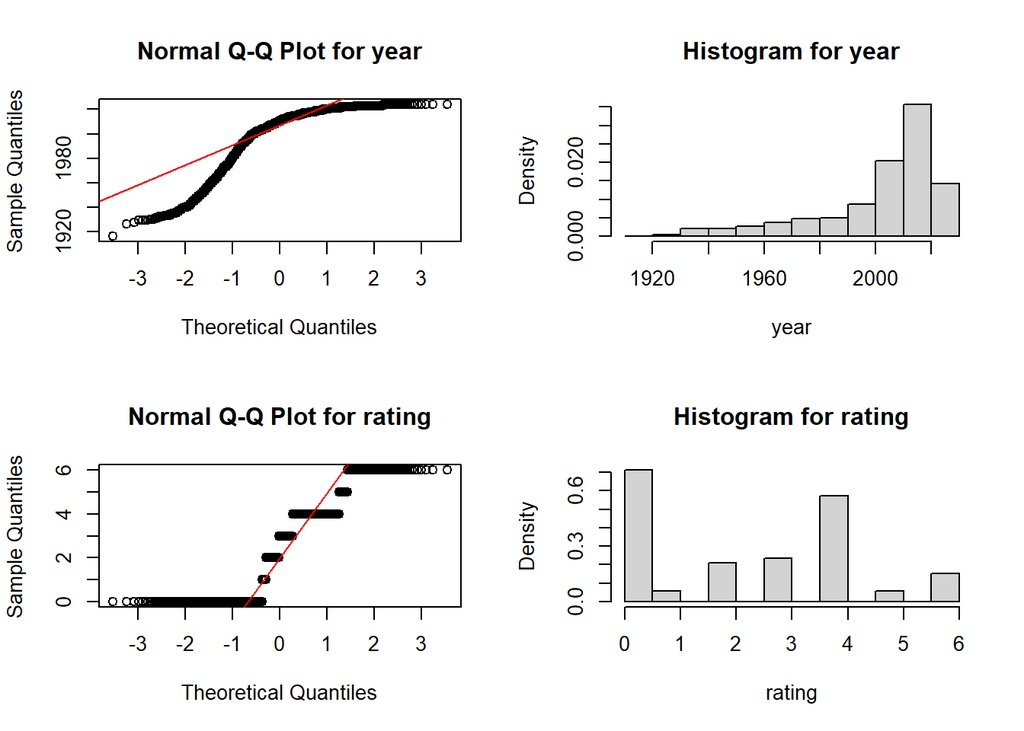

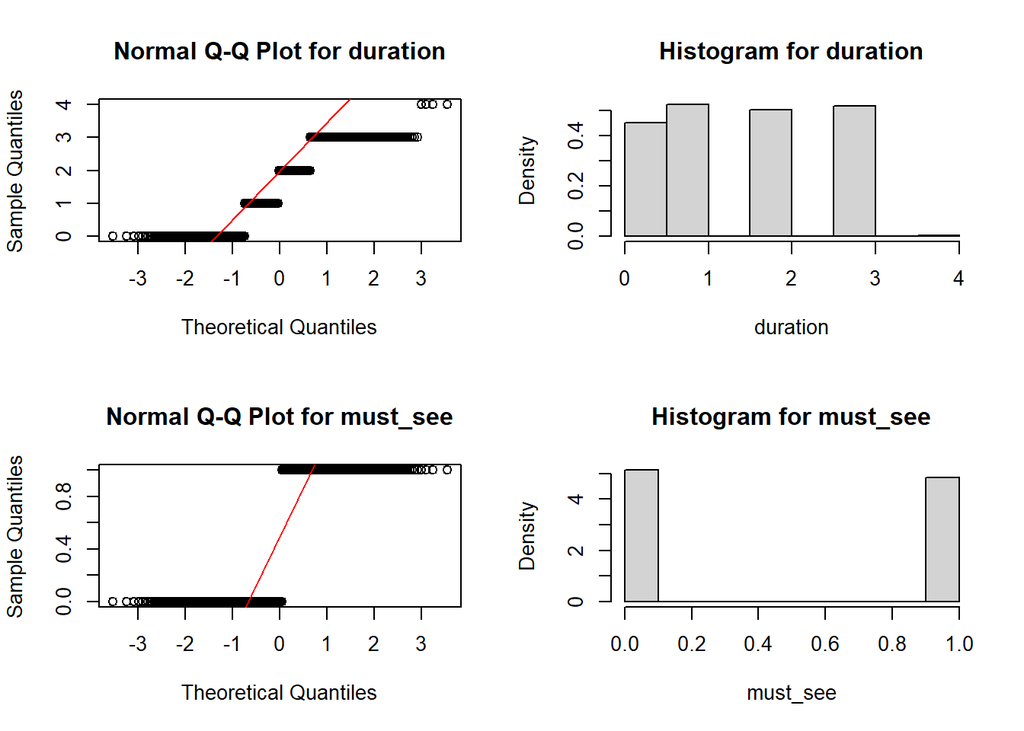

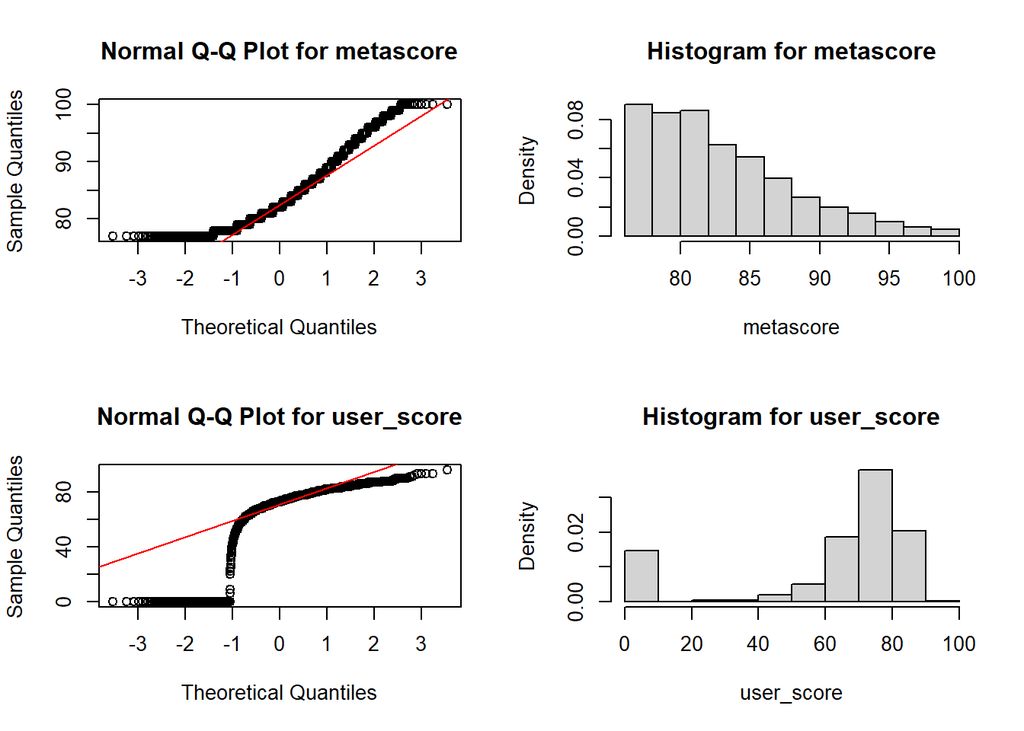

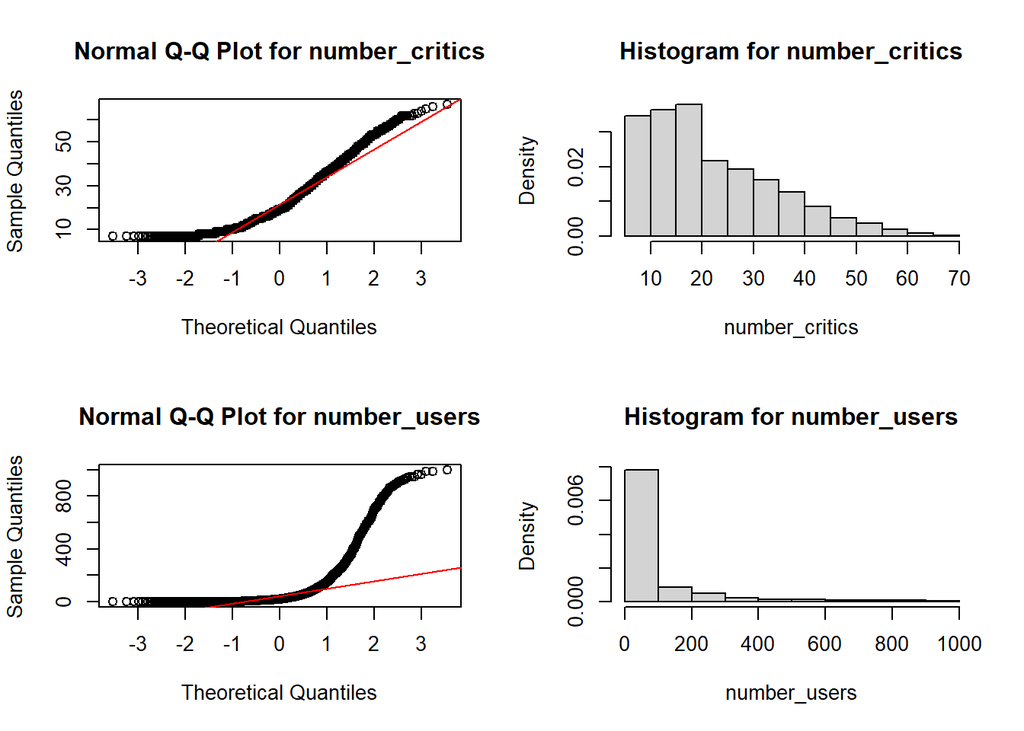

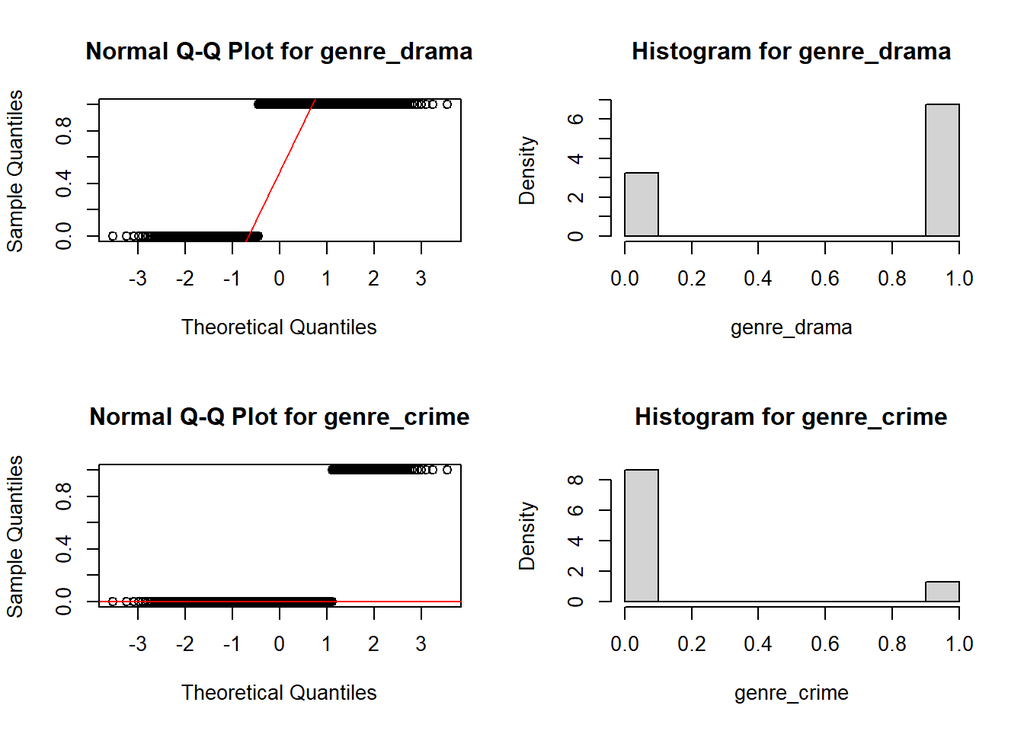

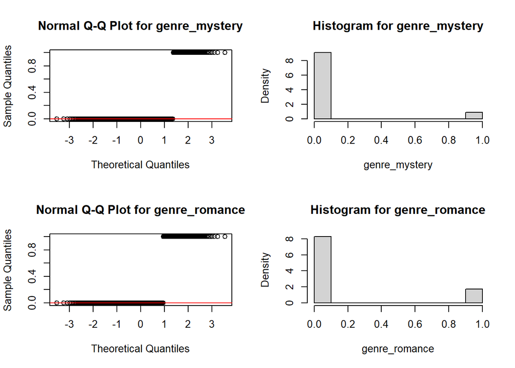

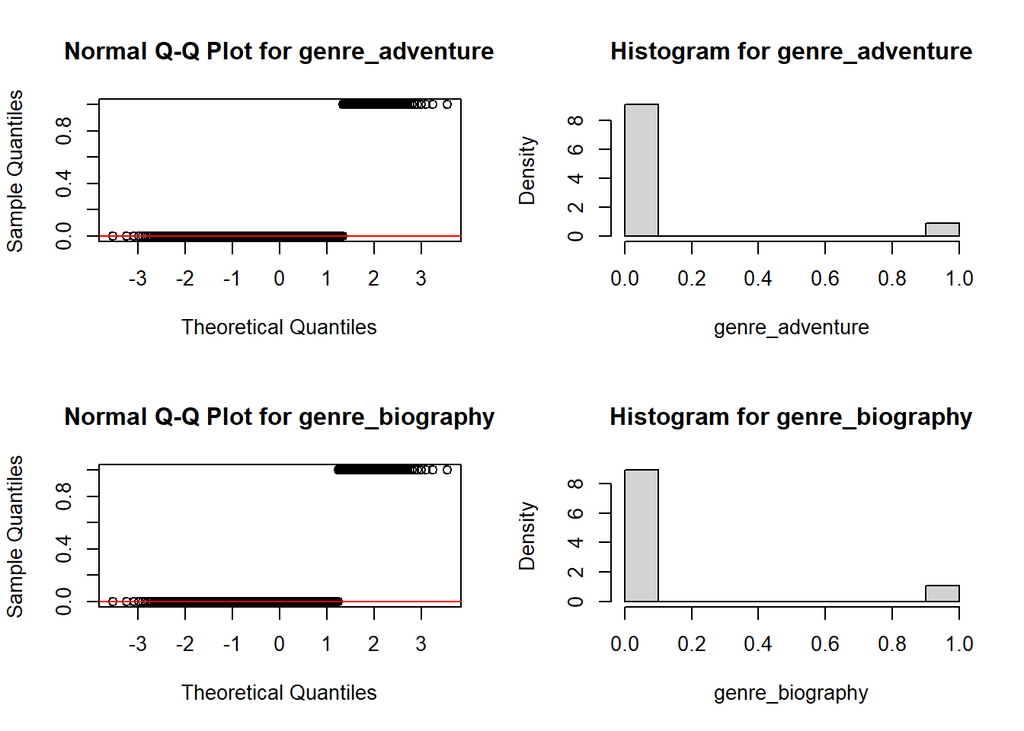

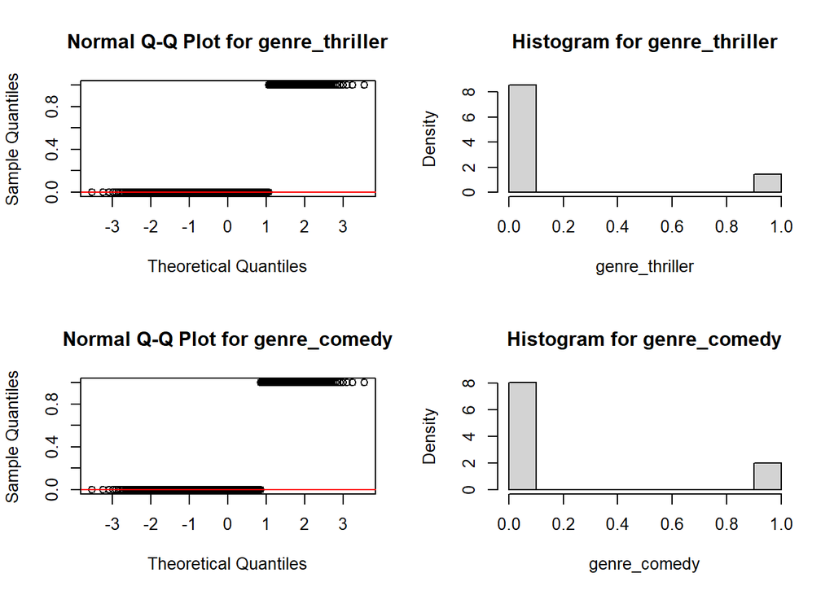

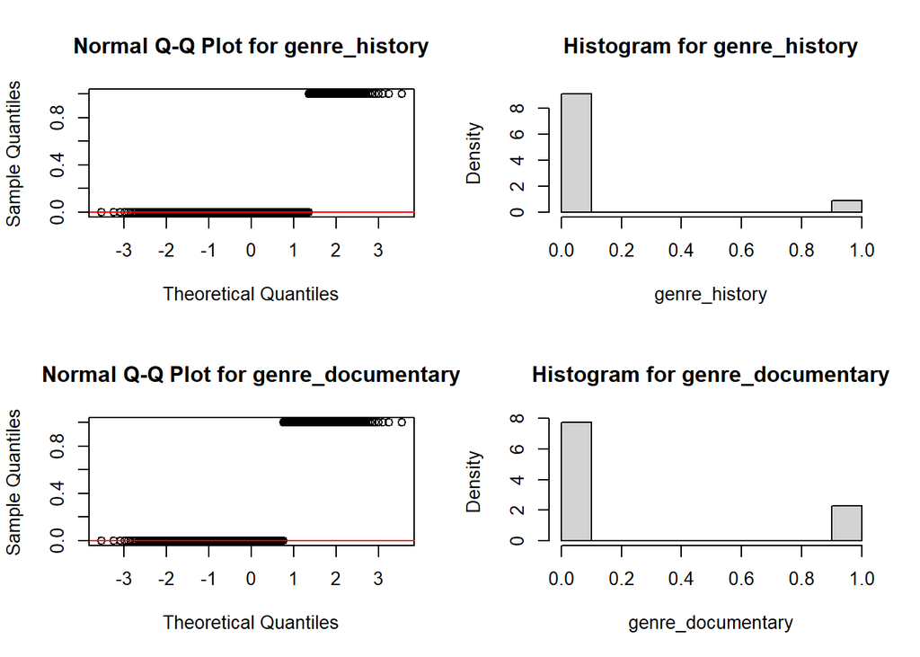

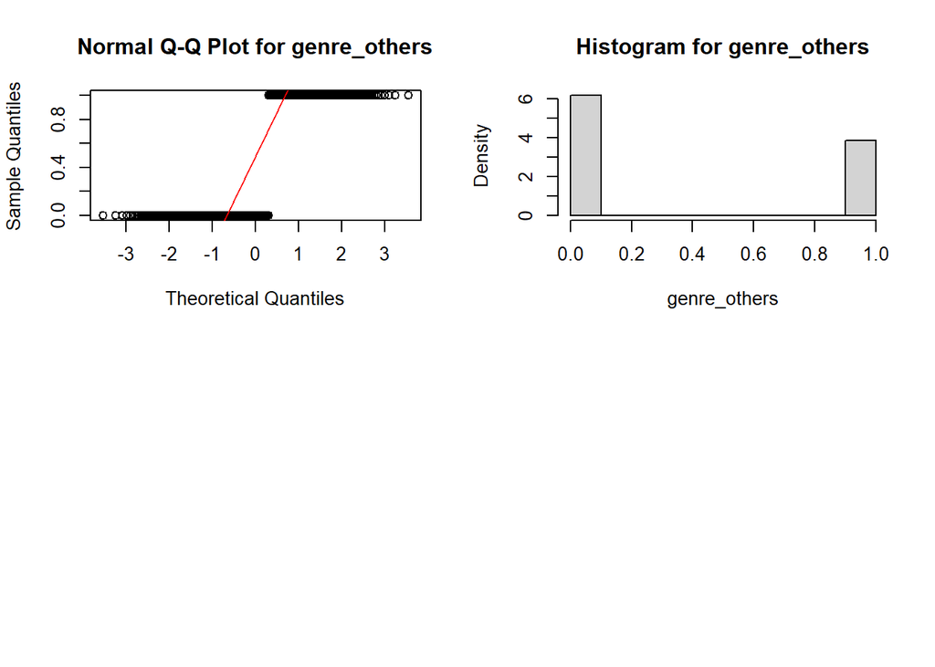

```r
par(mfrow=c(2,2))
for(i in 1:ncol(cleanData)) {
  if (is.numeric(cleanData[,i])){
    qqnorm(cleanData[,i],main = paste("Normal Q-Q Plot for",colnames(cleanData)[i]))
    qqline(cleanData[,i],col="red")
    hist(cleanData[,i],
      main=paste("Histogram for", colnames(cleanData)[i]),
      xlab=colnames(cleanData)[i], freq = FALSE)
  }
}
```

Los resultados del quantile-quantile plot nos indica que algunas variables pueden ser candidatas a la normalización si es necesario. Por ejemplo, las variables tipo factor (1/0) no tiene sentido normalizarlas y las codificadas tampoco.

Entonces nos quedariamos con: year, metascore, user_score, number_critics y number_users.

### Prueba de contraste de hipótesis de Shapiro-Wilk

Para revisar si las variables están normalizadas se aplica el test de Shapiro-Wilk en cada variables numérica de las antes mencionadas:

```r
shapiro.test(cleanData$year)
```

```
##
##  Shapiro-Wilk normality test
##
## data:  cleanData$year
## W = 0.81089, p-value < 2.2e-16
```

```r
shapiro.test(cleanData$metascore)
```

```
##
##  Shapiro-Wilk normality test
##
## data:  cleanData$metascore
## W = 0.91845, p-value < 2.2e-16
```

```r
shapiro.test(cleanData$user_score)
```

```
##
##  Shapiro-Wilk normality test
##
## data:  cleanData$user_score
## W = 0.69201, p-value < 2.2e-16
```

```r
shapiro.test(cleanData$number_critics)
```

```
##
##  Shapiro-Wilk normality test
##
## data:  cleanData$number_critics
## W = 0.91912, p-value < 2.2e-16
```

```r
shapiro.test(cleanData$number_users)
```

```
##
##  Shapiro-Wilk normality test
##
## data:  cleanData$number_users
## W = 0.5593, p-value < 2.2e-16
```

El test nos indica que ninguna variable esta normalizada, ya que el p-valor es inferior al coeficiente 0.05, por lo que se puede rechazar la hipotesis nula y entender que no es normal.

Que no sea normal no quiere decir que no pueda ser normalizable, ya que según el teorema del límite central, al tener más de 30 elementos en las observaciones, podemos aproximarla como una distribución normal de media 0 y desviación estándar 1.

```r
year.norm <- BoxCox(cleanData$year, lambda = BoxCoxLambda(cleanData$year))
shapiro.test(year.norm)
```

```
##
##  Shapiro-Wilk normality test
##
## data:  year.norm
## W = 0.81422, p-value < 2.2e-16
```

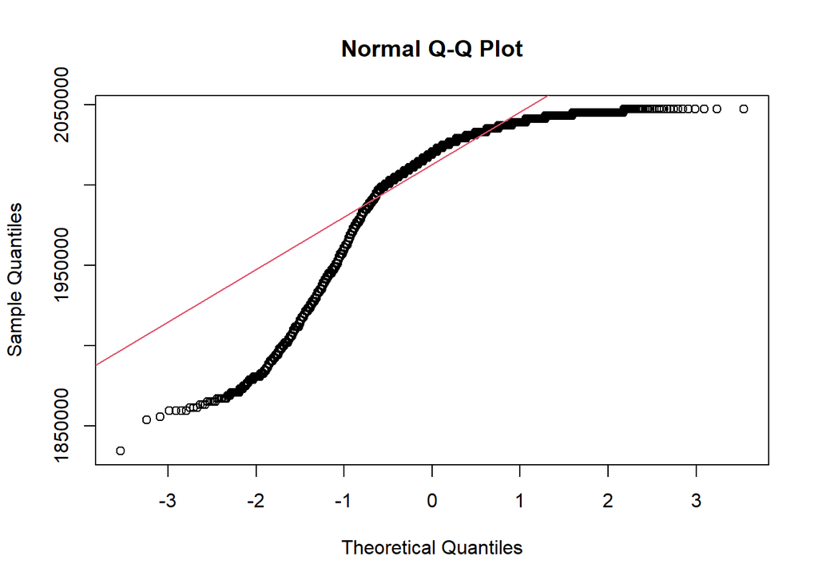

```r
qqnorm(year.norm)
qqline(year.norm, col=2)
```

En el caso de year, no mejora nada.

```r
metascore.norm <- BoxCox(cleanData$user_score, lambda = BoxCoxLambda(cleanData$user_score))
shapiro.test(metascore.norm)
```

```
##
##  Shapiro-Wilk normality test
##
## data:  metascore.norm
## W = 0.84978, p-value < 2.2e-16
```

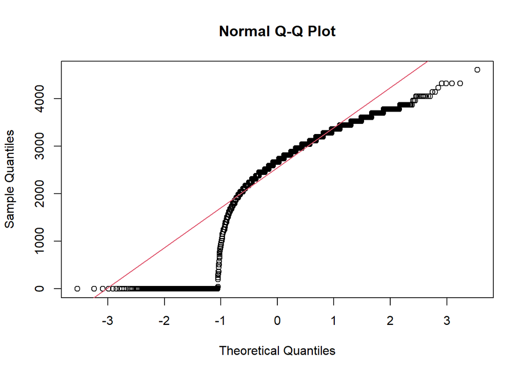

```r
qqnorm(metascore.norm)
qqline(metascore.norm, col=2)
```

Tampoco obtenemos mejores resultados de los ya tratados.

Se pueden probar tantas transformaciones como se desee, pero en este caso supondremos que los datos no se pueden normalizar y, por tanto, los analizaremos con pruebas que no presuponen estas caracteristicas.

### Prueba de contraste de hipótesis de Fligner-Killeeen

En referencia a la homogeneidad de la varianza, dado que los datos no son normales, usaremos el método de Fligner-Killeen, para comparar la varianza entre las puntuaciones y las variables factor:

```r
fligner.test(metascore ~ must_see, data = cleanData)
```

```
##
##  Fligner-Killeen test of homogeneity of variances
##
## data:  metascore by must_see
## Fligner-Killeen:med chi-squared = 90.749, df = 1, p-value < 2.2e-16
```

```r
fligner.test(metascore ~ rating, data = cleanData)
```

```
##
##  Fligner-Killeen test of homogeneity of variances
##
## data:  metascore by rating
## Fligner-Killeen:med chi-squared = 53.135, df = 6, p-value = 1.102e-09
```

### Prueba de contraste de hipótesis de Wilcoxon

Dado que los datos a analizar no presentan una distribución normal, las pruebas estadísticas para analizar y comparar los diferentes grupos deberán ser no paramétricas. Así, para los datos como los géneros que son booleanos, se aplica el test de Wilcoxon:

Probamos con drama:

```r
wilcox.test(cleanData$metascore~cleanData$genre_drama)
```

```
##
##  Wilcoxon rank sum test with continuity correction
##
## data:  cleanData$metascore by cleanData$genre_drama
## W = 626476, p-value = 0.0001161
## alternative hypothesis: true location shift is not equal to 0
```

Probamos con comedy:

```r
wilcox.test(cleanData$metascore~cleanData$genre_comedy)
```

```
##
##  Wilcoxon rank sum test with continuity correction
##
## data:  cleanData$metascore by cleanData$genre_comedy
## W = 513571, p-value = 0.3835
## alternative hypothesis: true location shift is not equal to 0
```

Por último, probamos con crime:

```r
wilcox.test(cleanData$metascore~cleanData$genre_crime)
```

```
##
##  Wilcoxon rank sum test with continuity correction
##
## data:  cleanData$metascore by cleanData$genre_crime
## W = 356513, p-value = 0.549
## alternative hypothesis: true location shift is not equal to 0
```

Podemos observar con la primera, que la diferencia entre los grupos es significativa (p<0.05). Es decir, el factor metascore es diferente cuando es la pelicula de drama o no, puede haber una relación. En cambio, cuando hemos aplicado el mismo modelo, pero con comedy y crime, vemos el factor p>0.05.

El test equivalente cuando se tienen 3 o más grupos de datos, como el caso de rating o duration, es el test de Kruskal-Wallis:

```r
kruskal.test(cleanData$metascore~cleanData$rating)
```

```
##
##  Kruskal-Wallis rank sum test
##
## data:  cleanData$metascore by cleanData$rating
## Kruskal-Wallis chi-squared = 110.83, df = 6, p-value < 2.2e-16
```

Son estadisticamente diferentes entre ellos.

Vamos a comprobar la correlación, a partir del método Spearman:

```r
cor.test(cleanData$genre_drama, cleanData$must_see,method="spearman")
```

```
##
##  Spearman's rank correlation rho
##
## data:  cleanData$genre_drama and cleanData$must_see
## S = 2361647189, p-value = 7.319e-08
## alternative hypothesis: true rho is not equal to 0
## sample estimates:
##       rho
## 0.1071287
```

No vemos mucha correlación.

### Modelo Supervisado

```r
data_glm<-cleanData[]

ntrain <- nrow(data_glm)*0.8
ntest <- nrow(data_glm)*0.2
set.seed(1)
index_train<-sample(1:nrow(data_glm),size = ntrain)
train<-data_glm[index_train,]
test<-data_glm[-index_train,]
modelo<-lm(formula = must_see ~ ., data=train)
summary(modelo)
```

```
##
## Call:
## lm(formula = must_see ~ ., data = train)
##
## Residuals:
##      Min       1Q   Median       3Q      Max
## -1.06985 -0.25934 -0.04703  0.31667  0.82302
##
## Coefficients:
##                     Estimate Std. Error t value Pr(>|t|)
## (Intercept)        2.100e-02  1.121e+00   0.019 0.985057
## year              -1.819e-03  5.340e-04  -3.407 0.000671 ***
## rating            -1.212e-02  5.117e-03  -2.368 0.017968 *
## duration          -1.412e-04  8.265e-03  -0.017 0.986373
## metascore          4.380e-02  1.787e-03  24.513  < 2e-16 ***
## user_score         1.545e-03  3.465e-04   4.460 8.66e-06 ***
## number_critics     1.635e-02  9.426e-04  17.343  < 2e-16 ***
## number_users      -3.581e-05  5.867e-05  -0.610 0.541736
## genre_drama        1.198e-02  2.729e-02   0.439 0.660830
## genre_crime        4.474e-02  2.716e-02   1.647 0.099709 .
## genre_mystery     -2.005e-02  3.215e-02  -0.624 0.532881
## genre_romance     -1.773e-03  2.361e-02  -0.075 0.940152
## genre_adventure   -3.879e-02  3.260e-02  -1.190 0.234202
## genre_biography    3.814e-03  2.911e-02   0.131 0.895766
## genre_thriller     3.531e-02  2.847e-02   1.240 0.215062
## genre_comedy       1.366e-02  2.287e-02   0.597 0.550413
## genre_history     -2.729e-02  3.112e-02  -0.877 0.380573
## genre_documentary  4.763e-02  3.480e-02   1.369 0.171306
## genre_others      -1.692e-02  1.899e-02  -0.891 0.373149
## ---
## Signif. codes:  0 '***' 0.001 '**' 0.01 '*' 0.05 '.' 0.1 ' ' 1
##
## Residual standard error: 0.3757 on 1991 degrees of freedom
## Multiple R-squared:  0.4403, Adjusted R-squared:  0.4353
## F-statistic: 87.02 on 18 and 1991 DF,  p-value: < 2.2e-16
```

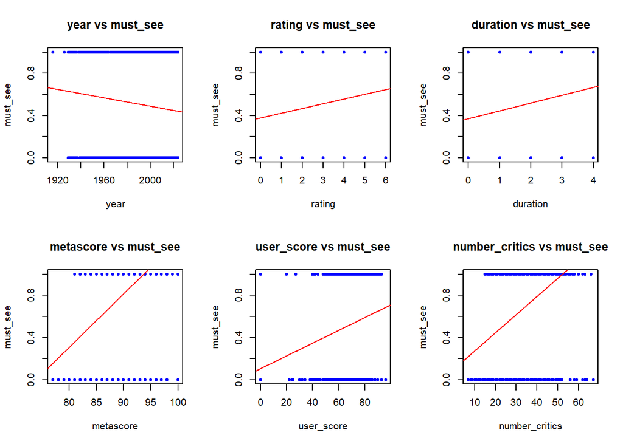

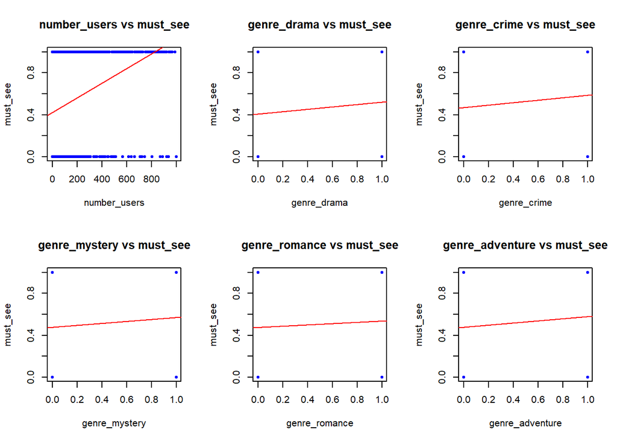

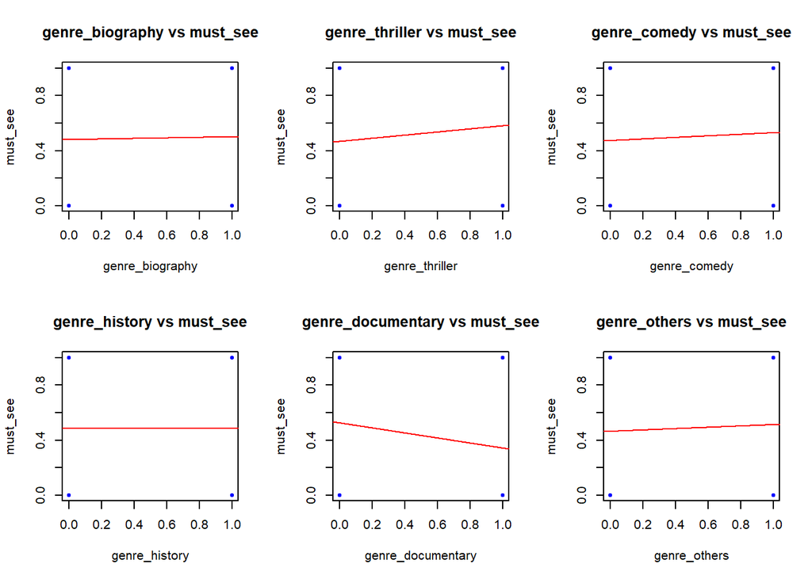

```r
cols <- setdiff(names(train), "must_see")

par(mfrow = c(2, 3))

for (col in cols) {
  plot(train[, col], train$must_see, main = paste0(col, " vs must_see"), xlab = col, ylab = "must_see", col = "blue", pch = 20)
  abline(lm(train$must_see ~ train[, col]), col = "red")
}
```

Gracias a estos gráficos, podemos determinar qué tipo de correlación posee cada campo con ‘must_see’. Por ejemplo, es lógico que, a mayor ‘metascore’, es decir, a mayor calificación de los críticos de la página de metacritic, mayor sea la probabilidad de que se etiquete como ‘must_see’, llegando al caso de que, si la película posee una puntuación de aproximadamente 95 o más, es casi seguro que reciba tal clasificación.

Otros casos que nos han parecido interesantes han sido que, conforme avancen los años, ‘must_see’ se reduzca; en otras palabras, existe una correlación negativa con ‘year’. Esto puede deberse a que la página ha recogido solo las mejores películas de los primeros años de cinematografía, que la calidad de las películas se haya reducido con el tiempo, que la crítica sea más “dura” con las nuevas películas, que dicha calificación necesite un periodo mínimo para poder recomendarse con esta etiqueta, etc.

### Modelo no supervisado

Usaremos clusters, para ello primero aplicaremos el codo de Jambú par escoger el número de clústeres que minimice la distancia intra-cluster:

```r
dataset_clu <- cleanData %>% dplyr::select(number_critics, must_see)
```

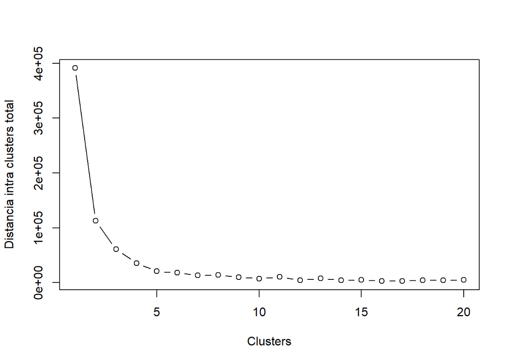

```r
ss = 1:20
for( i in 1:20){
  modelo = kmeans(x = dataset_clu, centers = i, iter.max = 20)
  ss[[i]] = modelo$tot.withinss
}
plot(1:20, ss, xlab = "Clusters", ylab = "Distancia intra clusters total",type = "b")
```

Los valores k=4 o k=5 serían una buena elección, dado que, a partir de ellos, los cambios no son significativos.

Quitamos las variables factor:

```r
summary(cleanData)
```

```
##       year          rating         duration        must_see
##  Min.   :1916   Min.   :0.000   Min.   :0.000   Min.   :0.0000
##  1st Qu.:1996   1st Qu.:0.000   1st Qu.:1.000   1st Qu.:0.0000
##  Median :2010   Median :3.000   Median :2.000   Median :0.0000
##  Mean   :2002   Mean   :2.343   Mean   :1.549   Mean   :0.4859
##  3rd Qu.:2018   3rd Qu.:4.000   3rd Qu.:3.000   3rd Qu.:1.0000
##  Max.   :2024   Max.   :6.000   Max.   :4.000   Max.   :1.0000
##                                 NA's   :1
##    metascore        user_score    number_critics   number_users
##  Min.   : 77.00   Min.   : 0.00   Min.   : 7.00   Min.   :  0.00
##  1st Qu.: 79.00   1st Qu.:63.00   1st Qu.:13.00   1st Qu.:  5.00
##  Median : 82.00   Median :73.00   Median :19.00   Median : 19.00
##  Mean   : 83.42   Mean   :62.72   Mean   :22.54   Mean   : 86.56
##  3rd Qu.: 86.00   3rd Qu.:79.00   3rd Qu.:30.00   3rd Qu.: 81.00
##  Max.   :100.00   Max.   :96.00   Max.   :67.00   Max.   :997.00
##
##   genre_drama      genre_crime     genre_mystery     genre_romance
##  Min.   :0.0000   Min.   :0.0000   Min.   :0.00000   Min.   :0.0000
##  1st Qu.:0.0000   1st Qu.:0.0000   1st Qu.:0.00000   1st Qu.:0.0000
##  Median :1.0000   Median :0.0000   Median :0.00000   Median :0.0000
##  Mean   :0.6757   Mean   :0.1329   Mean   :0.08754   Mean   :0.1727
##  3rd Qu.:1.0000   3rd Qu.:0.0000   3rd Qu.:0.00000   3rd Qu.:0.0000
##  Max.   :1.0000   Max.   :1.0000   Max.   :1.00000   Max.   :1.0000
##
##  genre_adventure   genre_biography  genre_thriller    genre_comedy
##  Min.   :0.00000   Min.   :0.0000   Min.   :0.0000   Min.   :0.0000
##  1st Qu.:0.00000   1st Qu.:0.0000   1st Qu.:0.0000   1st Qu.:0.0000
##  Median :0.00000   Median :0.0000   Median :0.0000   Median :0.0000
##  Mean   :0.09073   Mean   :0.1086   Mean   :0.1441   Mean   :0.1978
##  3rd Qu.:0.00000   3rd Qu.:0.0000   3rd Qu.:0.0000   3rd Qu.:0.0000
##  Max.   :1.00000   Max.   :1.0000   Max.   :1.0000   Max.   :1.0000
##
##  genre_history     genre_documentary  genre_others
##  Min.   :0.00000   Min.   :0.0000    Min.   :0.0000
##  1st Qu.:0.00000   1st Qu.:0.0000    1st Qu.:0.0000
##  Median :0.00000   Median :0.0000    Median :0.0000
##  Mean   :0.08874   Mean   :0.2264    Mean   :0.3836
##  3rd Qu.:0.00000   3rd Qu.:0.0000    3rd Qu.:1.0000
##  Max.   :1.00000   Max.   :1.0000    Max.   :1.0000
##
```

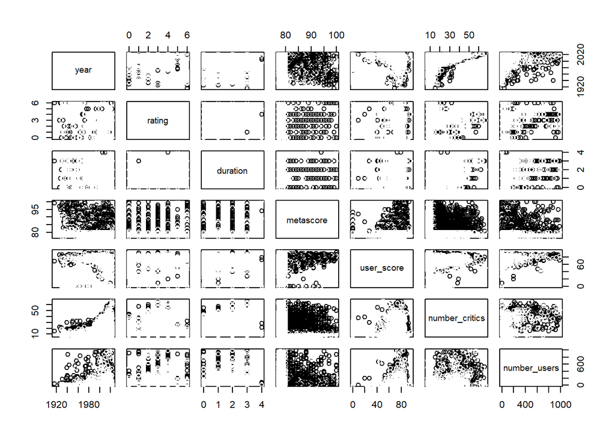

```r
pairs(cleanData[,-c(4,9,10,11,12,13,14,15,16,17,18,19)], col=cleanData$must_see)
```

```r
pca = PCA(cleanData[,-c(4,9,10,11,12,13,14,15,16,17,18,19)])
```

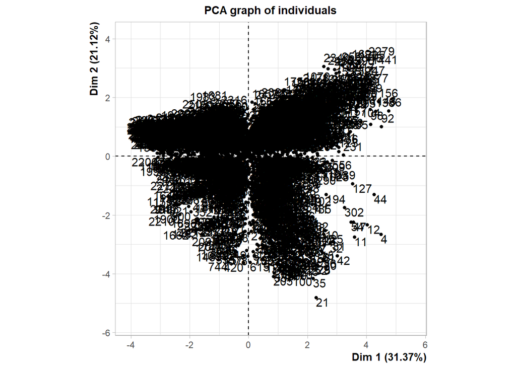

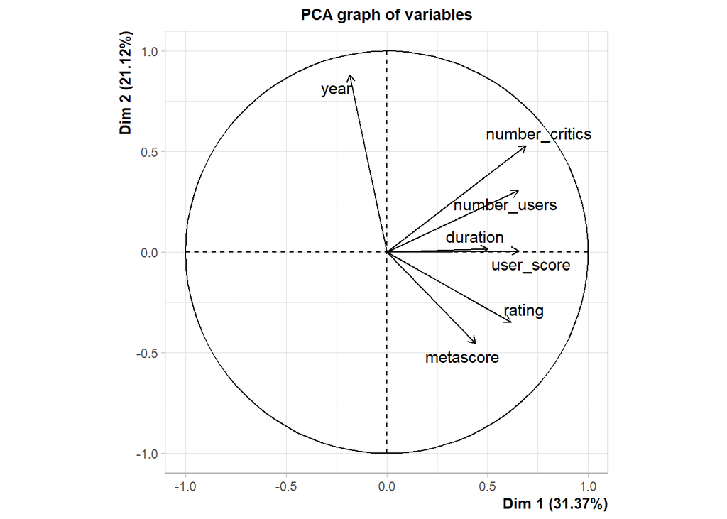

Al realizar el gráfico 2 a 2 de las variables del set de datos, y además, aplicando un análisis de componentes principales, nos podemos dar cuenta, que los datos parecen no ser separables. Por lo tanto, no existe alguna manera de detectar con una precisión aceptable, los elementos de una clase o de otra.

Aplicaremos un modelo de K-Medias, para observar los resultados y analizar el rendimiento luego, con el fin de dar soporte a lo anterior. Pero solo con las variables year, metascore y number_critics, porque las otras contienen ceros y este modelo no lo soporta:

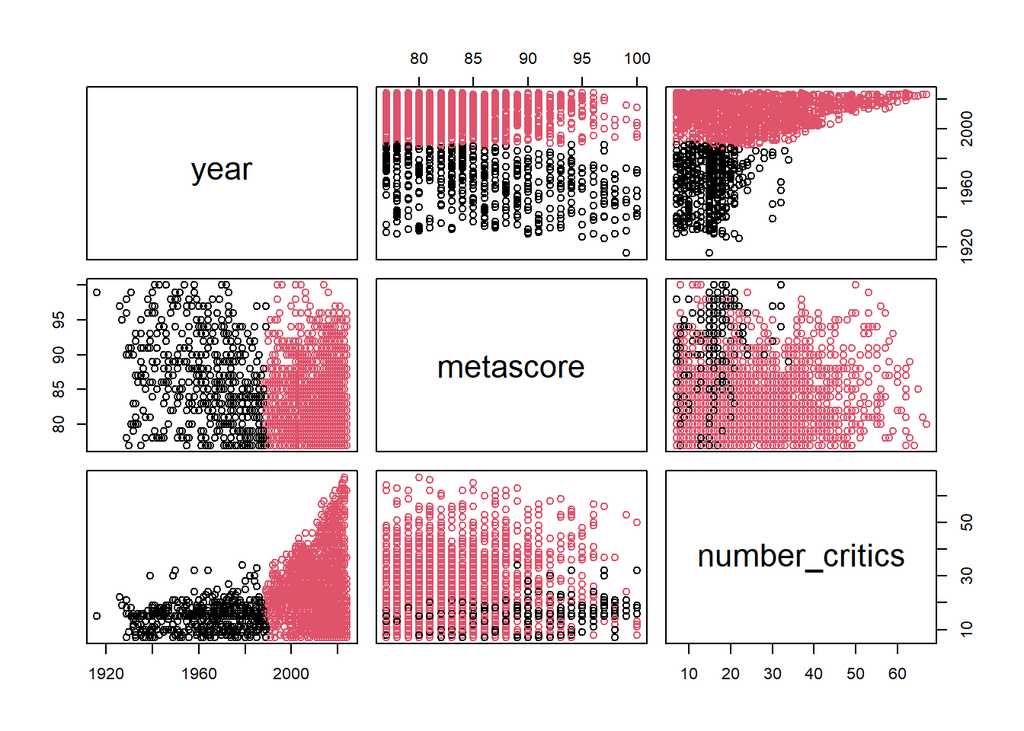

```r
cleanData.model = kmeans(cleanData[,-c(2,4,3,6,8,9,10,11,12,13,14,15,16,17,18,19)], centers=2, iter.max=20)
plot(cleanData[,-c(2,3,4,6,8,9,10,11,12,13,14,15,16,17,18,19)], col=cleanData.model$cluster)
```

Aquí se observa, por ejemplo, que cuanto más nueva es la película mayor es el número de críticos que la puntúan. Tiene sentido, ya que en las antiguas seguramente no había tantas opiniones informatizadas.

Evaluación del modelo:

```r
cleanData.conf = table(cleanData$must_see, cleanData.model$cluster, dnn=c("MustSee", "Cluster"))
cleanData.conf
```

```
##        Cluster
## MustSee    1    2
##       0  235 1057
##       1  261  960
```

## Conclusiones

Hemos podido comprobar que a mayor metascore mayor probabilidad de must_see, que es esperable y cuando mayor número de usuarios que han puntuado también mayor must_see.

Otro caso curioso, cuanto más dura la película hay una correlación positiva, probablemente sea más buena la película.

Y respecto a los géneros, si la película es de género drama, crimen, misterio, aventura o thriller tiene una ligera correlación positiva, mayor que en el resto. En cambio, en los documentales es negativa.

Y por último, el año, presenta correlación negativa, en cuanto más nueva sea la película menos probabilidad hay de que sea un must see.